# Cheatcode_RMED901_Final_exam

Prayash Chaudhary, Omar Omar, Osman Osman

## Introduction

The UiB organized a two weeks course on R programming language for the PhD students in the medical faculty. The overall aim of the course is to equip students with the valuable skills in data management, data analysis, visualization, and coding. During the two weeks course we learned the basics of R and we worked with the historical clinical trial dataset to practice data handling and analysis. The dataset comes from the 1948 Streptomycin for Tuberculosis trial whereby 107 were randomly assigned to take either sterptomycin (2g) daily or placebo. The dataset has been adopted for teaching purposes and contains information on patient demographics, baseline conditions, treatment assignment and six month outcomes.

## Tasks

### Task 1 Create an RStudio project and GitHub repository

The GitHub repository can be assessed with the following link: https://github.com/Prayash5522/Cheatcode_RMED901_Final_exam

### Task 2 Read and tidy the dataset

```r
library(here)
library(skimr)
library(naniar)
library(ggplot2)
library(GGally)
library(janitor)
library(tidyverse)
```

```r
original_data <- read_delim(here("data", "2025_09_05_original_exam_data.txt"))
```

#### Understanding the data

```r
skimr::skim(original_data)
```

Data summary

| Name | original_data |
| --- | --- |
| Number of rows | 141 |
| Number of columns | 14 |
| _______________________ |  |
| Column type frequency: |  |
| character | 8 |
| logical | 1 |
| numeric | 5 |
| ________________________ |  |
| Group variables | None |

**Variable type: character**

| skim_variable | n_missing | complete_rate | min | max | empty | n_unique | whitespace |
| --- | --- | --- | --- | --- | --- | --- | --- |
| gender | 0 | 1.00 | 1 | 1 | 0 | 2 | 0 |
| gender_arm | 0 | 1.00 | 9 | 14 | 0 | 4 | 0 |
| baseline_condition | 0 | 1.00 | 6 | 6 | 0 | 3 | 0 |
| baseline_temp_cat | 0 | 1.00 | 14 | 23 | 0 | 4 | 0 |
| baseline_esr_cat | 1 | 0.99 | 5 | 7 | 0 | 3 | 0 |
| baseline_cavitation | 0 | 1.00 | 2 | 3 | 0 | 2 | 0 |
| strep_resistance | 0 | 1.00 | 10 | 13 | 0 | 3 | 0 |
| 6m_radiologic | 0 | 1.00 | 7 | 28 | 0 | 6 | 0 |

**Variable type: logical**

| skim_variable | n_missing | complete_rate | mean | count |
| --- | --- | --- | --- | --- |
| improved | 0 | 1 | 0.51 | TRU: 72, FAL: 69 |

**Variable type: numeric**

| skim_variable | n_missing | complete_rate | mean | sd | p0 | p25 | p50 | p75 | p100 | hist |
| --- | --- | --- | --- | --- | --- | --- | --- | --- | --- | --- |
| patient_id | 0 | 1 | 57.50 | 30.49 | 1 | 32 | 60 | 83 | 107 | ▆▆▇▇▇ |
| month | 0 | 1 | 6.60 | 3.49 | 1 | 3 | 7 | 9 | 12 | ▇▃▅▇▇ |
| year | 0 | 1 | 2009.06 | 0.77 | 2008 | 2008 | 2009 | 2010 | 2010 | ▅▁▇▁▆ |
| dose_strep [g] | 0 | 1 | 1.15 | 0.99 | 0 | 0 | 2 | 2 | 2 | ▆▁▁▁▇ |
| rad_num | 0 | 1 | 3.92 | 1.88 | 1 | 2 | 5 | 6 | 6 | ▇▅▁▆▇ |

- NOTE: Separate baseline_condition into two parts but before that checking if 1 = good and so on and there are not any values where 1 or any other number is assigned to more than one category

```r
original_data %>% count(baseline_condition)
```

```
## # A tibble: 3 × 2
##   baseline_condition     n
##   <chr>              <int>
## 1 1_Good                20
## 2 2_Fair                49
## 3 3_Poor                72
```

- Comment: we find just 3 unique values: 1_good, 2_fair and 3_poor so now we are good to separate the baseline_condition into two part first

#### Separating baseline_condition

```r
original_data <- original_data %>%
  separate(baseline_condition, into = c("condition_number", "baseline_condition"))
```

###### Keeping the condition number while dropping variable baseline_condition and rename it to “good”, “fair” and “poor”

```r
original_data <- original_data %>% select(-baseline_condition)
```

```r
original_data <- original_data %>% rename(baseline_condition = "condition_number")

original_data <- original_data %>%
  mutate(baseline_condition = if_else(baseline_condition == 1, "good", baseline_condition),
         baseline_condition = if_else(baseline_condition == 2, "fair", baseline_condition),
         baseline_condition = if_else(baseline_condition == 3, "poor", baseline_condition))
```

- We seperated the gender_arm variable into two variables , one of them contain the gender and the other contain the arm

##### Delete the gender_arm variable

```r
original_data <- original_data %>%
      mutate(arm = sub(".*_", "", gender_arm)) %>%
      select(-gender_arm)
original_data
```

```
## # A tibble: 141 × 14
##    patient_id month  year gender `dose_strep [g]` baseline_condition
##         <dbl> <dbl> <dbl> <chr>             <dbl> <chr>
##  1          1     1  2009 M                     0 good
##  2          2     3  2008 F                     0 good
##  3          3    11  2010 F                     0 good
##  4          4    11  2008 M                     0 good
##  5          5     3  2009 F                     0 good
##  6          6     5  2008 M                     0 good
##  7          7     2  2009 F                     0 good
##  8          8     4  2008 M                     0 good
##  9          9    10  2010 F                     0 fair
## 10         10     9  2008 M                     0 fair
## # ℹ 131 more rows
## # ℹ 8 more variables: baseline_temp_cat <chr>, baseline_esr_cat <chr>,
## #   baseline_cavitation <chr>, strep_resistance <chr>, `6m_radiologic` <chr>,
## #   rad_num <dbl>, improved <lgl>, arm <chr>
```

#### Save the changes in a new data_set

```r
fileName <- paste0("2025_09_05_tidy_version_day1", ".txt")

write_delim(
  original_data,
  file = here("data", fileName),
  delim = "\t"
)
```

##### We rename the coloumn strep_resistance, and seperated it into two coloumns which called strep_resistance_level,

– strep_resistance

```r
original_data <- original_data %>%
  separate(strep_resistance, into = c("strep", "resistance"), sep = "_", extra = "merge")

print(original_data)
```

```
## # A tibble: 141 × 15
##    patient_id month  year gender `dose_strep [g]` baseline_condition
##         <dbl> <dbl> <dbl> <chr>             <dbl> <chr>
##  1          1     1  2009 M                     0 good
##  2          2     3  2008 F                     0 good
##  3          3    11  2010 F                     0 good
##  4          4    11  2008 M                     0 good
##  5          5     3  2009 F                     0 good
##  6          6     5  2008 M                     0 good
##  7          7     2  2009 F                     0 good
##  8          8     4  2008 M                     0 good
##  9          9    10  2010 F                     0 fair
## 10         10     9  2008 M                     0 fair
## # ℹ 131 more rows
## # ℹ 9 more variables: baseline_temp_cat <chr>, baseline_esr_cat <chr>,
## #   baseline_cavitation <chr>, strep <chr>, resistance <chr>,
## #   `6m_radiologic` <chr>, rad_num <dbl>, improved <lgl>, arm <chr>
```

```r
original_data <- original_data %>%
  mutate(strep = if_else(strep == 1, "sensitive", strep),
         strep = if_else(strep == 2, "modrate", strep),
         strep = if_else(strep == 3, "resistance", strep))

original_data <- original_data %>%
  separate(resistance, into = c("resistance", "concenteration_after_six_months"), sep = "_", extra = "merge")

print(original_data)
```

```
## # A tibble: 141 × 16
##    patient_id month  year gender `dose_strep [g]` baseline_condition
##         <dbl> <dbl> <dbl> <chr>             <dbl> <chr>
##  1          1     1  2009 M                     0 good
##  2          2     3  2008 F                     0 good
##  3          3    11  2010 F                     0 good
##  4          4    11  2008 M                     0 good
##  5          5     3  2009 F                     0 good
##  6          6     5  2008 M                     0 good
##  7          7     2  2009 F                     0 good
##  8          8     4  2008 M                     0 good
##  9          9    10  2010 F                     0 fair
## 10         10     9  2008 M                     0 fair
## # ℹ 131 more rows
## # ℹ 10 more variables: baseline_temp_cat <chr>, baseline_esr_cat <chr>,
## #   baseline_cavitation <chr>, strep <chr>, resistance <chr>,
## #   concenteration_after_six_months <chr>, `6m_radiologic` <chr>,
## #   rad_num <dbl>, improved <lgl>, arm <chr>
```

```r
original_data <- original_data %>%
  rename(strep_resistance_level = strep)

original_data <- original_data %>%
  rename(strep_resistance = concenteration_after_six_months)

original_data <- original_data %>% select(-resistance)
```

#### Dividing baseline_temp_cat into Fahrenheit and Celsius

```r
original_data <- original_data %>%
  separate(baseline_temp_cat, into = c("number_temp", "baseline_temp"),
           sep = 2) %>% select(-number_temp) %>%
  separate_wider_delim(baseline_temp, "/", names = c("baseline_temp_fahren", "baseline_temp_cels"))

original_data <- original_data %>%
  separate(baseline_temp_cels, into = c("baseline_temp_cels" , "number"),
           sep = -1) %>% select(-number)

original_data <- original_data %>%
  separate(baseline_temp_fahren, into = c("baseline_temp_fahren" , "number"),
           sep = -1) %>% select(-number)
```

#### Dividing baseline_esr_cat variable

```r
original_data <- original_data %>%
  separate(baseline_esr_cat, into = c(NA, "baseline_esr_cat"), sep = 2)
```

#### Dividing 6m_radiologica

```r
original_data <- original_data %>%
  separate(`6m_radiologic`, into = c(NA, "6m_radiologic"), sep = 2)
```

#### Saving the tidy dataset

```r
fileName <- paste0("2025_09_08_tidy_version_day2", ".txt")

write_delim(
  original_data,
  file = here("data", fileName),
  delim = "\t"
)
```

### Task 3 Tidy, adjust, and explore

#### Reading the tidy dataset

```r
tidy_data_day_2 <- read_delim(here("data", "2025_09_08_tidy_version_day2.txt"))
```

#### Removing -year, -month, -baseline_esr_cat variables

```r
tidy_data_day_2 <- tidy_data_day_2 %>% select(-year, -month, -baseline_esr_cat)

glimpse(tidy_data_day_2)
```

```
## Rows: 141
## Columns: 13
## $ patient_id             <dbl> 1, 2, 3, 4, 5, 6, 7, 8, 9, 10, 11, 12, 13, 14, …
## $ gender                 <chr> "M", "F", "F", "M", "F", "M", "F", "M", "F", "M…
## $ `dose_strep [g]`       <dbl> 0, 0, 0, 0, 0, 0, 0, 0, 0, 0, 0, 0, 0, 0, 0, 0,…
## $ baseline_condition     <chr> "good", "good", "good", "good", "good", "good",…
## $ baseline_temp_fahren   <chr> "<=98.9", "100-100.9", "<=98.9", "<=98.9", "99-…
## $ baseline_temp_cels     <chr> "37.2", "37.8-38.2", "37.2", "37.2", "37.3-37.7…
## $ baseline_cavitation    <chr> "yes", "no", "no", "no", "no", "no", "yes", "ye…
## $ strep_resistance_level <chr> "sensitive", "sensitive", "sensitive", "sensiti…
## $ strep_resistance       <chr> "0-8", "0-8", "0-8", "0-8", "0-8", "0-8", "0-8"…
## $ `6m_radiologic`        <chr> "Considerable_improvement", "Moderate_improveme…
## $ rad_num                <dbl> 6, 5, 5, 5, 5, 6, 5, 5, 5, 5, 6, 5, 5, 5, 5, 6,…
## $ improved               <lgl> TRUE, TRUE, TRUE, TRUE, TRUE, TRUE, TRUE, TRUE,…
## $ arm                    <chr> "Control", "Control", "Control", "Control", "Co…
```

- We removed the duplicates from the tidy_data_day_2 using the patient_id coloumn

```r
tidy_data_day_2 <- tidy_data_day_2 %>%
  distinct(patient_id, .keep_all = TRUE)
```

#### Import and assign the additional data set

```r
Additiona_data <- read_delim(here("data", "2025_09_05_original_exam_data_join.txt"))
```

#### Arrang both data sets tidy_data_day_2 and the Additiona_data by the patient_id

```r
tidy_data_day_2 <- tidy_data_day_2%>%
  arrange(patient_id)

Additiona_data <- Additiona_data%>%
  arrange(patient_id)

glimpse(Additiona_data)
```

```
## Rows: 107
## Columns: 3
## $ patient_id    <dbl> 1, 2, 3, 4, 5, 6, 7, 8, 9, 10, 11, 12, 13, 14, 15, 16, 1…
## $ baseline_temp <dbl> 98.73150, 100.59308, 98.57415, 98.56376, 99.17978, 100.3…
## $ baseline_esr  <dbl> 16, 13, 26, 27, 49, 23, 45, 47, 25, 38, 28, 29, 22, 22, …
```

#### Joining the tidy_data_day_2 and the Additiona_data into one file

```r
joined_data <- tidy_data_day_2 %>%
  left_join(Additiona_data, by = "patient_id")

glimpse(joined_data)
```

```
## Rows: 107
## Columns: 15
## $ patient_id             <dbl> 1, 2, 3, 4, 5, 6, 7, 8, 9, 10, 11, 12, 13, 14, …
## $ gender                 <chr> "M", "F", "F", "M", "F", "M", "F", "M", "F", "M…
## $ `dose_strep [g]`       <dbl> 0, 0, 0, 0, 0, 0, 0, 0, 0, 0, 0, 0, 0, 0, 0, 0,…
## $ baseline_condition     <chr> "good", "good", "good", "good", "good", "good",…
## $ baseline_temp_fahren   <chr> "<=98.9", "100-100.9", "<=98.9", "<=98.9", "99-…
## $ baseline_temp_cels     <chr> "37.2", "37.8-38.2", "37.2", "37.2", "37.3-37.7…
## $ baseline_cavitation    <chr> "yes", "no", "no", "no", "no", "no", "yes", "ye…
## $ strep_resistance_level <chr> "sensitive", "sensitive", "sensitive", "sensiti…
## $ strep_resistance       <chr> "0-8", "0-8", "0-8", "0-8", "0-8", "0-8", "0-8"…
## $ `6m_radiologic`        <chr> "Considerable_improvement", "Moderate_improveme…
## $ rad_num                <dbl> 6, 5, 5, 5, 5, 6, 5, 5, 5, 5, 6, 5, 5, 5, 5, 6,…
## $ improved               <lgl> TRUE, TRUE, TRUE, TRUE, TRUE, TRUE, TRUE, TRUE,…
## $ arm                    <chr> "Control", "Control", "Control", "Control", "Co…
## $ baseline_temp          <dbl> 98.73150, 100.59308, 98.57415, 98.56376, 99.179…
## $ baseline_esr           <dbl> 16, 13, 26, 27, 49, 23, 45, 47, 25, 38, 28, 29,…
```

#### Saving the joined_data

```r
fileName <- paste0("2025_09_08_joined_data_day2", ".txt")

write_delim(
  joined_data,
  file = here("data", fileName),
  delim = "\t"
)
```

#### Creating a set of new columns

##### Reading the joined dataset

```r
joined_data <- read_delim(here("data", "2025_09_08_joined_data_day2.txt"))
```

##### A column showing gender as “0” or “1” instead of “F” or “M”

```r
joined_data <- joined_data %>%
  mutate(gender = ifelse(gender == "F", 0, gender),
         gender = ifelse(gender == "M", 1, gender))
```

##### A coloumn that showes the strep resistance after the addministration of the high dose

- changing the values in the dose strep from 0-2 to no dose and high dose

```r
joined_data <- joined_data %>%
  mutate(`dose_strep [g]` = case_when(
    `dose_strep [g]` == 0 ~ "No_dose",
    `dose_strep [g]` == 2 ~ "high_dose",
    TRUE ~ as.character(`dose_strep [g]`)
  ))
```

##### Creating a new column that shows the resistance

```r
joined_data <- joined_data %>%
  mutate(
    status_after_high_dose_administration = case_when(
      `dose_strep [g]` == "high_dose" & strep_resistance_level == "resistance" ~ "resistant",
      `dose_strep [g]` == "high_dose" & strep_resistance_level == "sensitive" ~ "not_resistant",
      `dose_strep [g]` == "high_dose" & strep_resistance_level == "modrate" ~ "not_resistant",  # Fixed spelling
      `dose_strep [g]` == "No_dose" ~ "not_resistant",
      TRUE ~ "Unknown"
    )
  )
```

```r
glimpse(joined_data)
```

```
## Rows: 107
## Columns: 16
## $ patient_id                            <dbl> 1, 2, 3, 4, 5, 6, 7, 8, 9, 10, 1…
## $ gender                                <chr> "1", "0", "0", "1", "0", "1", "0…
## $ `dose_strep [g]`                      <chr> "No_dose", "No_dose", "No_dose",…
## $ baseline_condition                    <chr> "good", "good", "good", "good", …
## $ baseline_temp_fahren                  <chr> "<=98.9", "100-100.9", "<=98.9",…
## $ baseline_temp_cels                    <chr> "37.2", "37.8-38.2", "37.2", "37…
## $ baseline_cavitation                   <chr> "yes", "no", "no", "no", "no", "…
## $ strep_resistance_level                <chr> "sensitive", "sensitive", "sensi…
## $ strep_resistance                      <chr> "0-8", "0-8", "0-8", "0-8", "0-8…
## $ `6m_radiologic`                       <chr> "Considerable_improvement", "Mod…
## $ rad_num                               <dbl> 6, 5, 5, 5, 5, 6, 5, 5, 5, 5, 6,…
## $ improved                              <lgl> TRUE, TRUE, TRUE, TRUE, TRUE, TR…
## $ arm                                   <chr> "Control", "Control", "Control",…
## $ baseline_temp                         <dbl> 98.73150, 100.59308, 98.57415, 9…
## $ baseline_esr                          <dbl> 16, 13, 26, 27, 49, 23, 45, 47, …
## $ status_after_high_dose_administration <chr> "not_resistant", "not_resistant"…
```

- since we had created temperature variable in Fahrenheit and Celsius with the first baseline dataset, even before joining the data, we will drop the ones created before joining the data and use the baseline temperature from the data which was joined later

```r
joined_data <- joined_data %>% select(-baseline_temp_fahren, -baseline_temp_cels)

glimpse(joined_data)
```

```
## Rows: 107
## Columns: 14
## $ patient_id                            <dbl> 1, 2, 3, 4, 5, 6, 7, 8, 9, 10, 1…
## $ gender                                <chr> "1", "0", "0", "1", "0", "1", "0…
## $ `dose_strep [g]`                      <chr> "No_dose", "No_dose", "No_dose",…
## $ baseline_condition                    <chr> "good", "good", "good", "good", …
## $ baseline_cavitation                   <chr> "yes", "no", "no", "no", "no", "…
## $ strep_resistance_level                <chr> "sensitive", "sensitive", "sensi…
## $ strep_resistance                      <chr> "0-8", "0-8", "0-8", "0-8", "0-8…
## $ `6m_radiologic`                       <chr> "Considerable_improvement", "Mod…
## $ rad_num                               <dbl> 6, 5, 5, 5, 5, 6, 5, 5, 5, 5, 6,…
## $ improved                              <lgl> TRUE, TRUE, TRUE, TRUE, TRUE, TR…
## $ arm                                   <chr> "Control", "Control", "Control",…
## $ baseline_temp                         <dbl> 98.73150, 100.59308, 98.57415, 9…
## $ baseline_esr                          <dbl> 16, 13, 26, 27, 49, 23, 45, 47, …
## $ status_after_high_dose_administration <chr> "not_resistant", "not_resistant"…
```

```r
joined_data <- joined_data %>%
  mutate(baseline_temp_cels = (baseline_temp - 31)/(9/5))


glimpse(joined_data)
```

```
## Rows: 107
## Columns: 15
## $ patient_id                            <dbl> 1, 2, 3, 4, 5, 6, 7, 8, 9, 10, 1…
## $ gender                                <chr> "1", "0", "0", "1", "0", "1", "0…
## $ `dose_strep [g]`                      <chr> "No_dose", "No_dose", "No_dose",…
## $ baseline_condition                    <chr> "good", "good", "good", "good", …
## $ baseline_cavitation                   <chr> "yes", "no", "no", "no", "no", "…
## $ strep_resistance_level                <chr> "sensitive", "sensitive", "sensi…
## $ strep_resistance                      <chr> "0-8", "0-8", "0-8", "0-8", "0-8…
## $ `6m_radiologic`                       <chr> "Considerable_improvement", "Mod…
## $ rad_num                               <dbl> 6, 5, 5, 5, 5, 6, 5, 5, 5, 5, 6,…
## $ improved                              <lgl> TRUE, TRUE, TRUE, TRUE, TRUE, TR…
## $ arm                                   <chr> "Control", "Control", "Control",…
## $ baseline_temp                         <dbl> 98.73150, 100.59308, 98.57415, 9…
## $ baseline_esr                          <dbl> 16, 13, 26, 27, 49, 23, 45, 47, …
## $ status_after_high_dose_administration <chr> "not_resistant", "not_resistant"…
## $ baseline_temp_cels                    <dbl> 37.62861, 38.66282, 37.54119, 37…
```

##### Cutting “baseline_esr” score into quartiles (4 equal parts) and making a new variable

```r
joined_data <- joined_data %>%
  mutate(baseline_esr_quartiles = cut(baseline_esr, breaks = 4))

table(joined_data$baseline_esr_quartiles)
```

```
##
## (10.9,32.2] (32.2,53.5] (53.5,74.8] (74.8,96.1]
##          18          30          26          32
```

#### Setting the order of columns as: `patient_id, gender, arm` and other columns

```r
joined_data <- joined_data %>% select(patient_id, gender, arm, everything())

joined_data
```

```
## # A tibble: 107 × 16
##    patient_id gender arm     `dose_strep [g]` baseline_condition
##         <dbl> <chr>  <chr>   <chr>            <chr>
##  1          1 1      Control No_dose          good
##  2          2 0      Control No_dose          good
##  3          3 0      Control No_dose          good
##  4          4 1      Control No_dose          good
##  5          5 0      Control No_dose          good
##  6          6 1      Control No_dose          good
##  7          7 0      Control No_dose          good
##  8          8 1      Control No_dose          good
##  9          9 0      Control No_dose          fair
## 10         10 1      Control No_dose          fair
## # ℹ 97 more rows
## # ℹ 11 more variables: baseline_cavitation <chr>, strep_resistance_level <chr>,
## #   strep_resistance <chr>, `6m_radiologic` <chr>, rad_num <dbl>,
## #   improved <lgl>, baseline_temp <dbl>, baseline_esr <dbl>,
## #   status_after_high_dose_administration <chr>, baseline_temp_cels <dbl>,
## #   baseline_esr_quartiles <fct>
```

#### Arranging patient_id column of your data set in order of increasing number or alphabeticall

```r
joined_data <- joined_data %>% arrange(joined_data$patient_id)

head(joined_data)
```

```
## # A tibble: 6 × 16
##   patient_id gender arm     `dose_strep [g]` baseline_condition
##        <dbl> <chr>  <chr>   <chr>            <chr>
## 1          1 1      Control No_dose          good
## 2          2 0      Control No_dose          good
## 3          3 0      Control No_dose          good
## 4          4 1      Control No_dose          good
## 5          5 0      Control No_dose          good
## 6          6 1      Control No_dose          good
## # ℹ 11 more variables: baseline_cavitation <chr>, strep_resistance_level <chr>,
## #   strep_resistance <chr>, `6m_radiologic` <chr>, rad_num <dbl>,
## #   improved <lgl>, baseline_temp <dbl>, baseline_esr <dbl>,
## #   status_after_high_dose_administration <chr>, baseline_temp_cels <dbl>,
## #   baseline_esr_quartiles <fct>
```

```r
tail(joined_data)
```

```
## # A tibble: 6 × 16
##   patient_id gender arm          `dose_strep [g]` baseline_condition
##        <dbl> <chr>  <chr>        <chr>            <chr>
## 1        102 1      Streptomycin high_dose        poor
## 2        103 0      Streptomycin high_dose        poor
## 3        104 1      Streptomycin high_dose        poor
## 4        105 0      Streptomycin high_dose        poor
## 5        106 0      Streptomycin high_dose        poor
## 6        107 0      Streptomycin high_dose        poor
## # ℹ 11 more variables: baseline_cavitation <chr>, strep_resistance_level <chr>,
## #   strep_resistance <chr>, `6m_radiologic` <chr>, rad_num <dbl>,
## #   improved <lgl>, baseline_temp <dbl>, baseline_esr <dbl>,
## #   status_after_high_dose_administration <chr>, baseline_temp_cels <dbl>,
## #   baseline_esr_quartiles <fct>
```

#### Baseline_esr as numneric

```r
joined_data$baseline_esr <- as.numeric(joined_data$baseline_esr)

glimpse(joined_data)
```

```
## Rows: 107
## Columns: 16
## $ patient_id                            <dbl> 1, 2, 3, 4, 5, 6, 7, 8, 9, 10, 1…
## $ gender                                <chr> "1", "0", "0", "1", "0", "1", "0…
## $ arm                                   <chr> "Control", "Control", "Control",…
## $ `dose_strep [g]`                      <chr> "No_dose", "No_dose", "No_dose",…
## $ baseline_condition                    <chr> "good", "good", "good", "good", …
## $ baseline_cavitation                   <chr> "yes", "no", "no", "no", "no", "…
## $ strep_resistance_level                <chr> "sensitive", "sensitive", "sensi…
## $ strep_resistance                      <chr> "0-8", "0-8", "0-8", "0-8", "0-8…
## $ `6m_radiologic`                       <chr> "Considerable_improvement", "Mod…
## $ rad_num                               <dbl> 6, 5, 5, 5, 5, 6, 5, 5, 5, 5, 6,…
## $ improved                              <lgl> TRUE, TRUE, TRUE, TRUE, TRUE, TR…
## $ baseline_temp                         <dbl> 98.73150, 100.59308, 98.57415, 9…
## $ baseline_esr                          <dbl> 16, 13, 26, 27, 49, 23, 45, 47, …
## $ status_after_high_dose_administration <chr> "not_resistant", "not_resistant"…
## $ baseline_temp_cels                    <dbl> 37.62861, 38.66282, 37.54119, 37…
## $ baseline_esr_quartiles                <fct> "(10.9,32.2]", "(10.9,32.2]", "(…
```

#### Connecting above steps with pipe

- Since we have individually ran the codes above this is just an example of how we can pipe it all together. That’s why it is marked as a comment below:
- joined_data_xyz <- joined_data %>% mutate(gender = ifelse(gender == “F”, 0, gender), gender = ifelse(gender == “M”, 1, gender)) %>% mutate(`dose_strep [g]` = case_when( `dose_strep [g]` == 0 ~ “No_dose”, `dose_strep [g]` == 2 ~ “high_dose”, TRUE ~ as.character(`dose_strep [g]`) )) %>% mutate( status_after_high_dose_administration = case_when( `dose_strep [g]` == “high_dose” & strep_resistance_level == “resistance” ~ “resistant”, `dose_strep [g]` == “high_dose” & strep_resistance_level == “sensitive” ~ #“not_resistant”, `dose_strep [g]` == “high_dose” & strep_resistance_level == “modrate” ~ “not_resistant”#, `dose_strep [g]` == “No_dose” ~ “not_resistant”, TRUE ~ “Unknown”)) %>% select(-baseline_temp_fahren, -baseline_temp_cels) %>% mutate(baseline_temp_cels = (baseline_temp - 31)/(9/5)) %>% mutate(baseline_esr_quartile = cut(baseline_esr, breaks = 4)) %>% select(patient_id, gender, arm, everything()) %>% arrange(joined_data$patient_id)

#### Exploring missing data

```r
skimr:: skim(joined_data)
```

Data summary

| Name | joined_data |
| --- | --- |
| Number of rows | 107 |
| Number of columns | 16 |
| _______________________ |  |
| Column type frequency: |  |
| character | 9 |
| factor | 1 |
| logical | 1 |
| numeric | 5 |
| ________________________ |  |
| Group variables | None |

**Variable type: character**

| skim_variable | n_missing | complete_rate | min | max | empty | n_unique | whitespace |
| --- | --- | --- | --- | --- | --- | --- | --- |
| gender | 0 | 1 | 1 | 1 | 0 | 2 | 0 |
| arm | 0 | 1 | 7 | 12 | 0 | 2 | 0 |
| dose_strep [g] | 0 | 1 | 7 | 9 | 0 | 2 | 0 |
| baseline_condition | 0 | 1 | 4 | 4 | 0 | 3 | 0 |
| baseline_cavitation | 0 | 1 | 2 | 3 | 0 | 2 | 0 |
| strep_resistance_level | 0 | 1 | 7 | 10 | 0 | 3 | 0 |
| strep_resistance | 0 | 1 | 3 | 4 | 0 | 3 | 0 |
| 6m_radiologic | 0 | 1 | 5 | 26 | 0 | 6 | 0 |
| status_after_high_dose_administration | 0 | 1 | 9 | 13 | 0 | 2 | 0 |

**Variable type: factor**

| skim_variable | n_missing | complete_rate | ordered | n_unique | top_counts |
| --- | --- | --- | --- | --- | --- |
| baseline_esr_quartiles | 1 | 0.99 | FALSE | 4 | (74: 32, (32: 30, (53: 26, (10: 18 |

**Variable type: logical**

| skim_variable | n_missing | complete_rate | mean | count |
| --- | --- | --- | --- | --- |
| improved | 0 | 1 | 0.51 | TRU: 55, FAL: 52 |

**Variable type: numeric**

| skim_variable | n_missing | complete_rate | mean | sd | p0 | p25 | p50 | p75 | p100 | hist |
| --- | --- | --- | --- | --- | --- | --- | --- | --- | --- | --- |
| patient_id | 0 | 1.00 | 54.00 | 31.03 | 1.00 | 27.50 | 54.00 | 80.50 | 107.00 | ▇▇▇▇▇ |
| rad_num | 0 | 1.00 | 3.93 | 1.89 | 1.00 | 2.00 | 5.00 | 6.00 | 6.00 | ▇▅▁▆▇ |
| baseline_temp | 0 | 1.00 | 100.71 | 1.18 | 98.46 | 99.66 | 100.59 | 101.79 | 102.63 | ▃▅▇▅▇ |
| baseline_esr | 1 | 0.99 | 57.83 | 23.57 | 11.00 | 37.25 | 58.50 | 79.50 | 96.00 | ▅▆▇▆▇ |
| baseline_temp_cels | 0 | 1.00 | 38.73 | 0.65 | 37.48 | 38.14 | 38.66 | 39.33 | 39.79 | ▃▅▇▅▇ |

- Comment: We have one baseline_esr value missing. The observation is for a participant in control arm, with poor baseline condition, at was dead at the 6 month follow up.

#### Stratifying categorical_variable to report report min, max, mean and sd of a numeric column

##### Stratifying all categorical_variable

```r
Stratifying_all_categorical_variable <- joined_data %>%
  group_by(across(where(~ is.factor(.) || is.character(.)))) %>%  # all categorical vars
  summarise(
    min_baseline_temp = min(baseline_temp, na.rm = TRUE),
    max_baseline_temp = max(baseline_temp, na.rm = TRUE),
    mean_baseline_temp = mean(baseline_temp, na.rm = TRUE),
    sd_baseline_temp = sd(baseline_temp, na.rm = TRUE),
    .groups = "drop"
  )

glimpse(Stratifying_all_categorical_variable)
```

```
## Rows: 80
## Columns: 14
## $ gender                                <chr> "0", "0", "0", "0", "0", "0", "0…
## $ arm                                   <chr> "Control", "Control", "Control",…
## $ `dose_strep [g]`                      <chr> "No_dose", "No_dose", "No_dose",…
## $ baseline_condition                    <chr> "fair", "fair", "fair", "fair", …
## $ baseline_cavitation                   <chr> "no", "no", "no", "no", "yes", "…
## $ strep_resistance_level                <chr> "sensitive", "sensitive", "sensi…
## $ strep_resistance                      <chr> "0-8", "0-8", "0-8", "0-8", "0-8…
## $ `6m_radiologic`                       <chr> "Considerable_improvement", "Mod…
## $ status_after_high_dose_administration <chr> "not_resistant", "not_resistant"…
## $ baseline_esr_quartiles                <fct> "(10.9,32.2]", "(32.2,53.5]", "(…
## $ min_baseline_temp                     <dbl> 100.07647, 100.74734, 99.40201, …
## $ max_baseline_temp                     <dbl> 100.07647, 100.75476, 99.40201, …
## $ mean_baseline_temp                    <dbl> 100.07647, 100.75105, 99.40201, …
## $ sd_baseline_temp                      <dbl> NA, 0.005247918, NA, NA, NA, 0.0…
```

##### Stratifying gender with baseline_temp

```r
stratify_gender_temp <- joined_data %>%
  group_by(gender) %>%
  summarise(
    min_baseline_temp = min(baseline_temp, na.rm = TRUE),
    max_baseline_temp = max(baseline_temp, na.rm = TRUE),
    mean_baseline_temp = mean(baseline_temp, na.rm = TRUE),
    sd_baseline_temp = sd(baseline_temp, na.rm = TRUE),
  )

glimpse(stratify_gender_temp)
```

```
## Rows: 2
## Columns: 5
## $ gender             <chr> "0", "1"
## $ min_baseline_temp  <dbl> 98.45755, 98.52052
## $ max_baseline_temp  <dbl> 102.6306, 102.2899
## $ mean_baseline_temp <dbl> 100.7474, 100.6586
## $ sd_baseline_temp   <dbl> 1.218784, 1.132755
```

##### Stratifying different varibables for the value of rad_num

- baseline_condition is fair

```r
stratify_fair_rad_num <- joined_data %>%
  group_by(baseline_condition) %>% filter(baseline_condition == "fair") %>%
  summarise(
    min_rad_num = min(rad_num, na.rm = TRUE),
    max_rad_num = max(rad_num, na.rm = TRUE),
    mean_rad_num = mean(rad_num, na.rm = TRUE),
    sd_rad_num = sd(rad_num, na.rm = TRUE),
  )

glimpse(stratify_fair_rad_num)
```

```
## Rows: 1
## Columns: 5
## $ baseline_condition <chr> "fair"
## $ min_rad_num        <dbl> 2
## $ max_rad_num        <dbl> 6
## $ mean_rad_num       <dbl> 4.567568
## $ sd_rad_num         <dbl> 1.344547
```

- only for females

```r
stratify_females_rad_num <- joined_data %>%
  group_by(gender) %>% filter(gender == 0) %>%
  summarise(
    min_rad_num = min(rad_num, na.rm = TRUE),
    max_rad_num = max(rad_num, na.rm = TRUE),
    mean_rad_num = mean(rad_num, na.rm = TRUE),
    sd_rad_num = sd(rad_num, na.rm = TRUE),
  )

glimpse(stratify_females_rad_num)
```

```
## Rows: 1
## Columns: 5
## $ gender       <chr> "0"
## $ min_rad_num  <dbl> 1
## $ max_rad_num  <dbl> 6
## $ mean_rad_num <dbl> 3.694915
## $ sd_rad_num   <dbl> 1.905113
```

```r
stratify_temp_rad_num <- joined_data %>%
  mutate(
    baseline_tempt100_100.9F =
      if_else(baseline_temp >= 0 & baseline_temp <= 100.9, 1, 0)) %>%
  group_by(baseline_tempt100_100.9F) %>%
  filter(baseline_tempt100_100.9F == 1) %>%
  summarise(
    min_rad_num  = min(rad_num, na.rm = TRUE),
    max_rad_num  = max(rad_num, na.rm = TRUE),
    mean_rad_num = mean(rad_num, na.rm = TRUE),
    sd_rad_num   = sd(rad_num, na.rm = TRUE)
  )
glimpse(stratify_temp_rad_num)
```

```
## Rows: 1
## Columns: 5
## $ baseline_tempt100_100.9F <dbl> 1
## $ min_rad_num              <dbl> 1
## $ max_rad_num              <dbl> 6
## $ mean_rad_num             <dbl> 4.428571
## $ sd_rad_num               <dbl> 1.672494
```

- Only for persons that developed resistance to streptomycin

```r
stratify_resistance_rad_num <- joined_data %>%
  mutate(
    resistance_streptomycin =
      if_else(strep_resistance_level == "resistance", 1, 0)) %>%
  group_by(resistance_streptomycin) %>%
  filter(resistance_streptomycin == 1) %>%
  summarise(
    min_rad_num  = min(rad_num, na.rm = TRUE),
    max_rad_num  = max(rad_num, na.rm = TRUE),
    mean_rad_num = mean(rad_num, na.rm = TRUE),
    sd_rad_num   = sd(rad_num, na.rm = TRUE)
  )
glimpse(stratify_resistance_rad_num)
```

```
## Rows: 1
## Columns: 5
## $ resistance_streptomycin <dbl> 1
## $ min_rad_num             <dbl> 1
## $ max_rad_num             <dbl> 6
## $ mean_rad_num            <dbl> 4.088235
## $ sd_rad_num              <dbl> 1.864625
```

#### Example of two categorical columns in one table

```r
gender_strep_resistance <- joined_data %>% janitor::tabyl(gender,strep_resistance_level)

gender_strep_resistance
```

```
##  gender modrate resistance sensitive
##       0       5         19        35
##       1       3         15        30
```

### Task 4 Create plots that would help answer these questions:

#### Are there any correlated measurements? (hint: `GGally::ggcorr` or search online for correlation matrix in R) ?

- For answering this questions , we made a heat map that shows the correlation between each numerical variable
- Selection of the numerical variable

```r
correlation_check <- joined_data %>%
  select(where(is.numeric))
```

- Plotting of the heat map for all the numerical variables

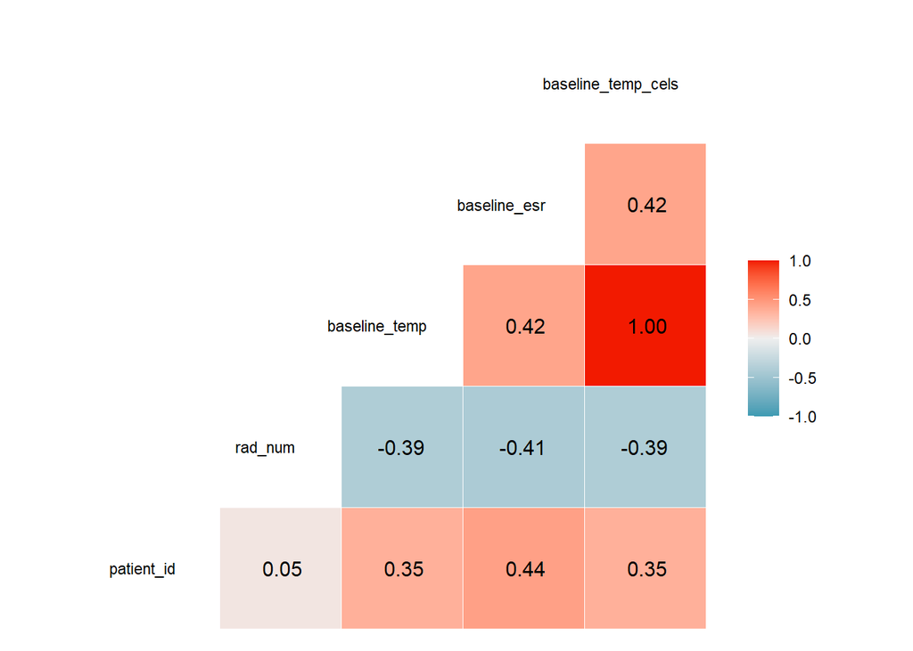

```r
ggcorr(correlation_check,
       label = TRUE,                # show correlation coefficients
       label_round = 2,             # round decimals
       hjust = 0.75, size = 3)      # adjust label placement & size
```

- comment: if we wanted to see the variable names

```r
names(correlation_check)
```

```
## [1] "patient_id"         "rad_num"            "baseline_temp"
## [4] "baseline_esr"       "baseline_temp_cels"
```

#### Does the erythrocyte sedimentation rate in mm per hour at baseline distribution depend on `gender`?

- If we were to assign the names of the observation within the gender, male = 1 , female = 0 joined_data <- joined_data %>% mutate(gender = if_else(gender, levels = c(0, 1), labels = c(“Female”, “Male”)))
- Ploting the curve comaring between the male and female

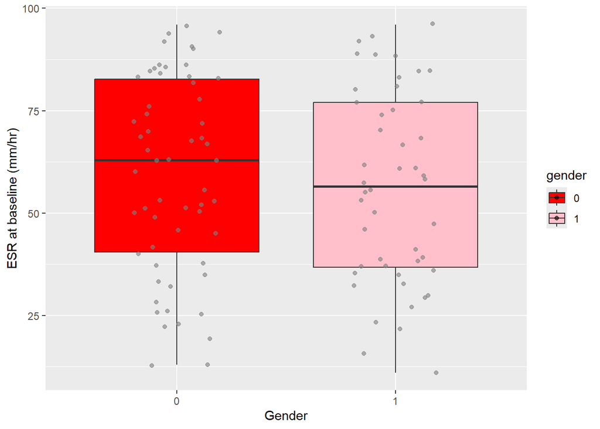

```r
ggplot(joined_data, aes(x = gender, y = baseline_esr, fill = gender)) +
  geom_boxplot() +
  geom_jitter(aes(color = "black"), width = 0.2, alpha = 0.6) +
  scale_fill_manual(values = c("1" = "pink", "0" = "red")) +
  scale_color_manual(values = c("1" = "pink", "0" = "red")) +
  labs(x = "Gender", y = "ESR at baseline (mm/hr)")
```

```r
  labs(x = "Gender", y = "ESR at baseline (mm/hr)") # 0 is female and # 1 is male
```

```
## $x
## [1] "Gender"
##
## $y
## [1] "ESR at baseline (mm/hr)"
##
## attr(,"class")
## [1] "labels"
```

```r
joined_data %>%
  t.test(baseline_esr ~ gender, data = .) %>%
  broom::tidy()
```

```
## # A tibble: 1 × 10
##   estimate estimate1 estimate2 statistic p.value parameter conf.low conf.high
##      <dbl>     <dbl>     <dbl>     <dbl>   <dbl>     <dbl>    <dbl>     <dbl>
## 1     3.12      59.2      56.1     0.677   0.500      101.    -6.02      12.2
## # ℹ 2 more variables: method <chr>, alternative <chr>
```

#### Do erythrocyte sedimentation rate in mm per hour at baseline and baseline temperature have a linear relationship?

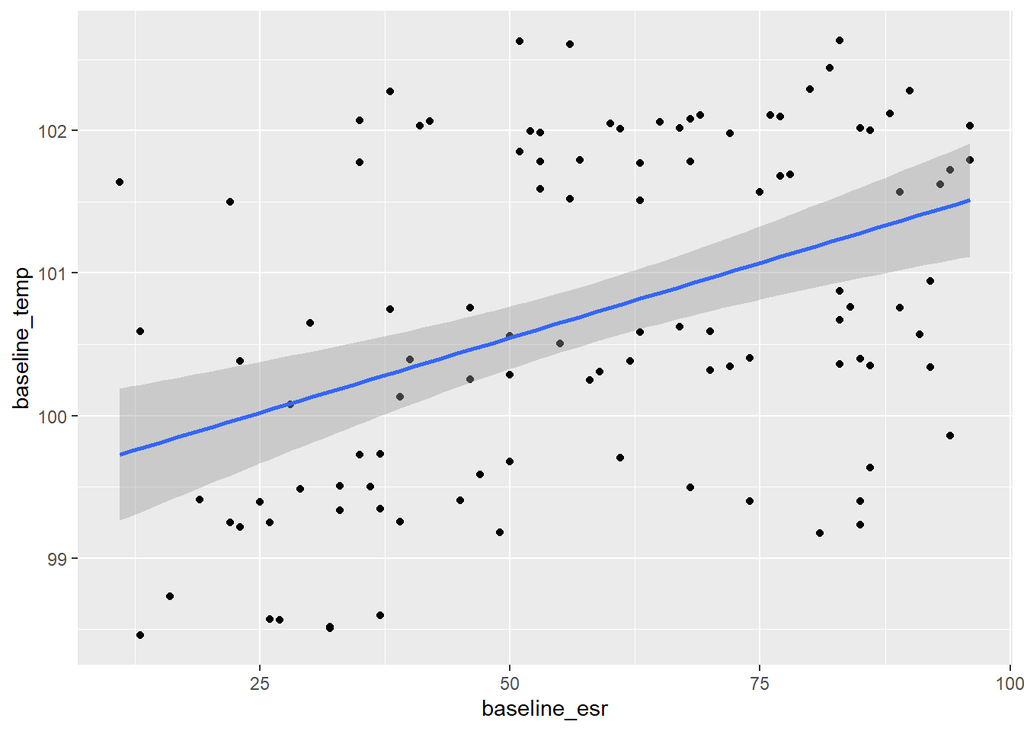

```r
#visual inspection
joined_data %>%
  ggplot(aes(x = baseline_esr, y = baseline_temp)) +
  geom_point() +
  geom_smooth(method = "lm")
```

- Comment: the visual inspection suggests that erythrocyte sedimentation rate in mm per hour at baseline and baseline temperature seems to have a linear relation

##### running linear regression to confirm

- display numbers/p-values in standard (non-scientific) format

```r
options(scipen = 999)
```

```r
joined_data %>%
  lm(baseline_esr ~ baseline_temp, data = .) %>%
  broom::tidy()
```

```
## # A tibble: 2 × 5
##   term          estimate std.error statistic    p.value
##   <chr>            <dbl>     <dbl>     <dbl>      <dbl>
## 1 (Intercept)    -785.      179.       -4.39 0.0000277
## 2 baseline_temp     8.37      1.78      4.71 0.00000771
```

- very low p-value seems to align with the estimation made through visual inspection above.

### Task 5

#### Does the randomization arm depend on the gender?

```r
glimpse(joined_data)
```

```
## Rows: 107
## Columns: 16
## $ patient_id                            <dbl> 1, 2, 3, 4, 5, 6, 7, 8, 9, 10, 1…
## $ gender                                <chr> "1", "0", "0", "1", "0", "1", "0…
## $ arm                                   <chr> "Control", "Control", "Control",…
## $ `dose_strep [g]`                      <chr> "No_dose", "No_dose", "No_dose",…
## $ baseline_condition                    <chr> "good", "good", "good", "good", …
## $ baseline_cavitation                   <chr> "yes", "no", "no", "no", "no", "…
## $ strep_resistance_level                <chr> "sensitive", "sensitive", "sensi…
## $ strep_resistance                      <chr> "0-8", "0-8", "0-8", "0-8", "0-8…
## $ `6m_radiologic`                       <chr> "Considerable_improvement", "Mod…
## $ rad_num                               <dbl> 6, 5, 5, 5, 5, 6, 5, 5, 5, 5, 6,…
## $ improved                              <lgl> TRUE, TRUE, TRUE, TRUE, TRUE, TR…
## $ baseline_temp                         <dbl> 98.73150, 100.59308, 98.57415, 9…
## $ baseline_esr                          <dbl> 16, 13, 26, 27, 49, 23, 45, 47, …
## $ status_after_high_dose_administration <chr> "not_resistant", "not_resistant"…
## $ baseline_temp_cels                    <dbl> 37.62861, 38.66282, 37.54119, 37…
## $ baseline_esr_quartiles                <fct> "(10.9,32.2]", "(10.9,32.2]", "(…
```

```r
table(joined_data$arm, joined_data$gender)
```

```
##
##                 0  1
##   Control      28 24
##   Streptomycin 31 24
```

```r
chisq.test(joined_data$arm, joined_data$gender) %>%
  broom::tidy()
```

```
## # A tibble: 1 × 4
##   statistic p.value parameter method
##       <dbl>   <dbl>     <int> <chr>
## 1   0.00452   0.946         1 Pearson's Chi-squared test with Yates' continuity…
```

– Comment: since the p value is 0.946, at the significance level of 95% confidence interval,we can conclude that randomization does not depend on the gender.

#### Does the randomization arm depend on erythrocyte sedimentation rate in mm per hour at baseline?

```r
glimpse(joined_data)
```

```
## Rows: 107
## Columns: 16
## $ patient_id                            <dbl> 1, 2, 3, 4, 5, 6, 7, 8, 9, 10, 1…
## $ gender                                <chr> "1", "0", "0", "1", "0", "1", "0…
## $ arm                                   <chr> "Control", "Control", "Control",…
## $ `dose_strep [g]`                      <chr> "No_dose", "No_dose", "No_dose",…
## $ baseline_condition                    <chr> "good", "good", "good", "good", …
## $ baseline_cavitation                   <chr> "yes", "no", "no", "no", "no", "…
## $ strep_resistance_level                <chr> "sensitive", "sensitive", "sensi…
## $ strep_resistance                      <chr> "0-8", "0-8", "0-8", "0-8", "0-8…
## $ `6m_radiologic`                       <chr> "Considerable_improvement", "Mod…
## $ rad_num                               <dbl> 6, 5, 5, 5, 5, 6, 5, 5, 5, 5, 6,…
## $ improved                              <lgl> TRUE, TRUE, TRUE, TRUE, TRUE, TR…
## $ baseline_temp                         <dbl> 98.73150, 100.59308, 98.57415, 9…
## $ baseline_esr                          <dbl> 16, 13, 26, 27, 49, 23, 45, 47, …
## $ status_after_high_dose_administration <chr> "not_resistant", "not_resistant"…
## $ baseline_temp_cels                    <dbl> 37.62861, 38.66282, 37.54119, 37…
## $ baseline_esr_quartiles                <fct> "(10.9,32.2]", "(10.9,32.2]", "(…
```

```r
joined_data %>%
  t.test(baseline_esr ~ arm, data = .) %>%
  broom::tidy()
```

```
## # A tibble: 1 × 10
##   estimate estimate1 estimate2 statistic p.value parameter conf.low conf.high
##      <dbl>     <dbl>     <dbl>     <dbl>   <dbl>     <dbl>    <dbl>     <dbl>
## 1    -4.17      55.7      59.8    -0.907   0.366      102.    -13.3      4.94
## # ℹ 2 more variables: method <chr>, alternative <chr>
```

- Comment: since the p-value is 0.366, at the significance level of 95% confidence interval, we can conclude that randomization does not depend of erythrocyte sedimentation rate in mm per hour at baseline.

##### Is there an association between streptomycin resistance after 6 months of therapy and erythrocyte sedimentation rate in mm per hour at baseline?

```r
joined_data %>%
  mutate(baseline_esr = log(baseline_esr)) %>%
  aov(baseline_esr ~ strep_resistance_level, data =.) %>%
  summary()
```

```
##                         Df Sum Sq Mean Sq F value Pr(>F)
## strep_resistance_level   2  1.486  0.7431   3.082 0.0501 .
## Residuals              103 24.835  0.2411
## ---
## Signif. codes:  0 '***' 0.001 '**' 0.01 '*' 0.05 '.' 0.1 ' ' 1
## 1 observation deleted due to missingness
```

- Comment: I made anova test to do that because I have continues and categorical data which need to use anova the p-value is not statistically significant = 0.05, that’s why strep resistance level don’t affect the baseline-esr.

- One way ANOVA

```r
joined_data %>%
  mutate(baseline_esr = log(baseline_esr)) %>% aov(baseline_esr ~ `6m_radiologic` , data =.) %>%
  summary()
```

```
##                  Df Sum Sq Mean Sq F value   Pr(>F)
## `6m_radiologic`   5  5.445  1.0890   5.216 0.000269 ***
## Residuals       100 20.877  0.2088
## ---
## Signif. codes:  0 '***' 0.001 '**' 0.01 '*' 0.05 '.' 0.1 ' ' 1
## 1 observation deleted due to missingness
```